# VAR

Hairo Ulises Miranda Belmonte

11 de Junio del 2019

```r
library("vars")
library(magrittr)
library(tidyverse)
knitr::opts_chunk$set(message=FALSE)
```

## MODELO 1

```r
# DATES TASA DE INTERES
setwd("C:/Users/h_air/Desktop/Minutas/England")
library(readxl)
datos <- read_excel("Contraste.xlsx")
datos$DATE <- datos$DATE %>% as.Date()
datos <- datos %>% as.data.frame
# Filtrar fecha que no se necesita
datos <- datos %>% filter(!DATE=="1998-10-21")
```

```r
base2 <- datos %>% filter(DATE>="1997-10-15" &DATE<="2014-02-19")
```

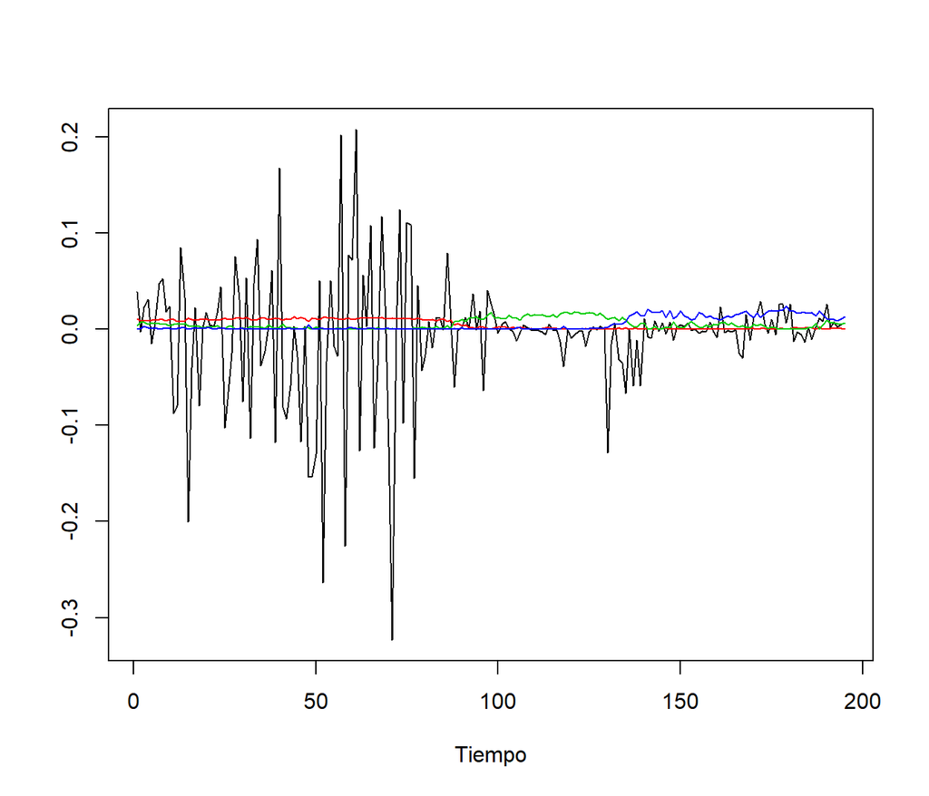

```r
setwd("C:/Users/h_air/Desktop/Minutas/England")

w3_2 <-read.csv("w3_2.csv")
w3_2 <- as.data.frame(w3_2) %>% column_to_rownames(var="X")
base22 <- base2[order(base2$DATE ),]

X <- cbind(as.data.frame(rownames(w3_2)),base2$...1, w3_2)
Clasificador1 <-X
tasa <- ((base22$DESPUES/100)-(base22$ANTES/100))/(base22$ANTES/100)
series <- cbind(tasa, Clasificador1[,3:5])
ts.plot(series, xlab="Tiempo",col=c(1,2,3,4))
```

**Seleccion del LAG**

```r
VARselect(diff(as.matrix(series)),lag.max=10,type="const")
```

```
## $selection
## AIC(n)  HQ(n)  SC(n) FPE(n)
##      3      2      2      3
##
## $criteria
##                    1             2             3             4
## AIC(n) -4.469808e+01 -4.506375e+01 -4.509536e+01 -4.502382e+01
## HQ(n)  -4.455644e+01 -4.480881e+01 -4.472711e+01 -4.454225e+01
## SC(n)  -4.434863e+01 -4.443474e+01 -4.418679e+01 -4.383569e+01
## FPE(n)  3.871628e-20  2.686562e-20  2.604615e-20  2.801063e-20
##                    5             6             7             8
## AIC(n) -4.501593e+01 -4.491821e+01 -4.476464e+01 -4.467046e+01
## HQ(n)  -4.442106e+01 -4.421003e+01 -4.394315e+01 -4.373566e+01
## SC(n)  -4.354825e+01 -4.317096e+01 -4.273783e+01 -4.236409e+01
## FPE(n)  2.828550e-20  3.127575e-20  3.660714e-20  4.042763e-20
##                    9            10
## AIC(n) -4.455927e+01 -4.441503e+01
## HQ(n)  -4.351116e+01 -4.325361e+01
## SC(n)  -4.197335e+01 -4.154954e+01
## FPE(n)  4.547849e-20  5.296714e-20
```

```r
#ts.plot(diff(as.matrix(series)),xlab="Tiempo", col=c(1,2,3,4))
```

**1.2. Paso 2: EstimaciÓN del Modelo VAR**

```r
names(series) <- c("tasa","w1","w2","w3")
modelo<-VAR(diff(as.matrix(series)),p=3,type=c("const"))
# A continuacion solicitaremos un resumen de cada ecuaciÃ³n por separado:
summary(modelo,equation="tasa")
```

```
##
## VAR Estimation Results:
## =========================
## Endogenous variables: tasa, w1, w2, w3
## Deterministic variables: const
## Sample size: 191
## Log Likelihood: 3284.883
## Roots of the characteristic polynomial:
## 0.7748 0.7748 0.7236 0.6486 0.6486 0.5171 0.445 0.445 0.429 0.429 0.3307 0.09172
## Call:
## VAR(y = diff(as.matrix(series)), p = 3, type = c("const"))
##
##
## Estimation results for equation tasa:
## =====================================
## tasa = tasa.l1 + w1.l1 + w2.l1 + w3.l1 + tasa.l2 + w1.l2 + w2.l2 + w3.l2 + tasa.l3 + w1.l3 + w2.l3 + w3.l3 + const
##
##           Estimate Std. Error t value Pr(>|t|)
## tasa.l1 -0.9145392  0.0694872 -13.161  < 2e-16 ***
## w1.l1    4.5606207  8.4067953   0.542    0.588
## w2.l1    4.1004098  4.8461699   0.846    0.399
## w3.l1    1.1423206  4.1904871   0.273    0.785
## tasa.l2 -0.7216917  0.0813307  -8.874 7.41e-16 ***
## w1.l2   10.8953247  9.3117591   1.170    0.244
## w2.l2    2.2505103  5.2313109   0.430    0.668
## w3.l2    1.1261359  4.6690239   0.241    0.810
## tasa.l3 -0.3907166  0.0694534  -5.626 7.06e-08 ***
## w1.l3    3.8539042  8.2612271   0.467    0.641
## w2.l3    2.8410369  4.7969373   0.592    0.554
## w3.l3    2.7899242  4.1441167   0.673    0.502
## const    0.0003641  0.0050822   0.072    0.943
## ---
## Signif. codes:  0 '***' 0.001 '**' 0.01 '*' 0.05 '.' 0.1 ' ' 1
##
##
## Residual standard error: 0.06952 on 178 degrees of freedom
## Multiple R-Squared: 0.5268,  Adjusted R-squared: 0.4949
## F-statistic: 16.51 on 12 and 178 DF,  p-value: < 2.2e-16
##
##
##
## Covariance matrix of residuals:
##            tasa         w1         w2         w3
## tasa  4.833e-03 -3.375e-06 -3.045e-06 -2.787e-07
## w1   -3.375e-06  9.313e-07 -1.050e-06 -2.914e-07
## w2   -3.045e-06 -1.050e-06  3.778e-06 -1.895e-06
## w3   -2.787e-07 -2.914e-07 -1.895e-06  3.557e-06
##
## Correlation matrix of residuals:
##           tasa       w1       w2        w3
## tasa  1.000000 -0.05031 -0.02253 -0.002125
## w1   -0.050305  1.00000 -0.55995 -0.160076
## w2   -0.022534 -0.55995  1.00000 -0.516988
## w3   -0.002125 -0.16008 -0.51699  1.000000
```

**1.3. Paso 3: EvaluaciÃ³n del Modelo**

1.3.1. Prueba de Estacionariedad (Condicion de Estabilidad de los Estimadores) vamos a ver si cumple la condicion de estabilidad prueba de estacionariedad demultiple variables que mencionamos anteriormente

Recordemos que un proceso autorregresivo univariado es estacionario si todas las raices de $Ï(z)=0$ se encuentran fuera del circulo unitario.

```r
roots(modelo)
```

```
##  [1] 0.77478448 0.77478448 0.72361989 0.64855465 0.64855465 0.51710776
##  [7] 0.44504095 0.44504095 0.42899514 0.42899514 0.33067136 0.09172097
```

La comprobación de la estabilidad no indica que nuestro modelo este mal.

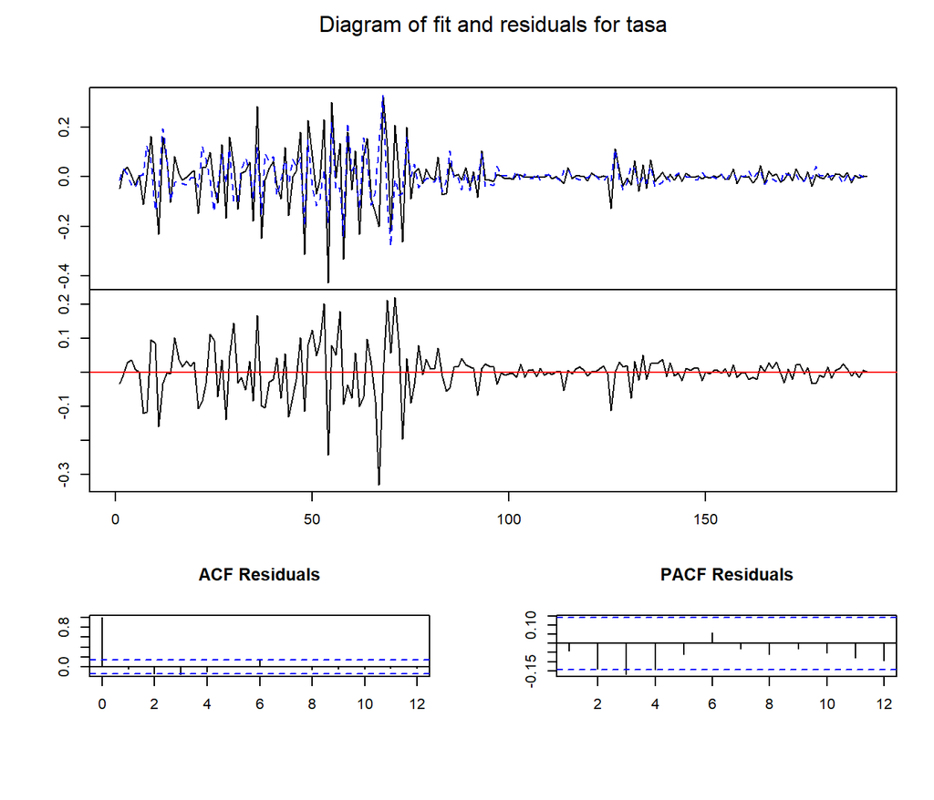

```r
# 1.3.2. Analisis de Autocorrelacion en los Residuales
x11()
plot(modelo, names="tasa")
```

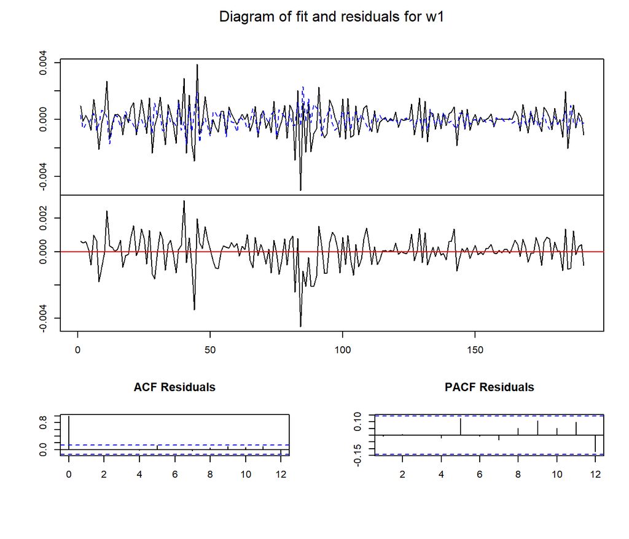

```r
plot(modelo, names="w1")
```